일변량 자료의 탐색

Contents

# 1. 자료의 종류

통계 기법은 자료를 정리하고 분석할 수 있는 강력한 수단  
데이터 분석 에서도 많은 부분에서 통계적 기법을 필요로 한다

## 1.1 변수 형태

### 1.1.1 질적 자료(qualitative data) 또는 범주형 자료(categorical data)

: 원칙적으로 숫자로 표시될 수 없는 자료  
예) 교육수준 : 초졸, 중졸, 고졸, 대졸 / 성별 : M, F

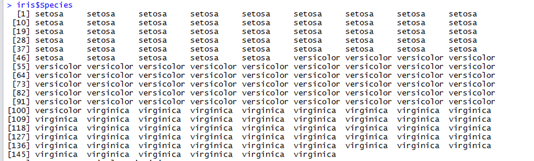

### 1.1.2 양적 자료(quantitative data) 또는 연속형 자료

: 자료 자체가 크기가 있는 숫자로 표현됨

- 이산자료(discrete data) : 정수값을 취할 수 있는 자료(각 세대의 자녀 수)
- 연속자료(continuous data) : 실수 값을 취할 수 있는 자료(키, 몸무게, 온도)

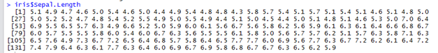

## 1.2 변수 개수

### 1.2.1 일변량 자료(univariate data)

- 분석대상이 되는 변수의 개수가 1개
- ex) 단국대 학생들의 몸무게 분포를 분석해보자
- vector 에 저장하여 분석

### 1.2.2 다변량 자료 (multivariate data)

- 분석대상이 되는 변수의 개수가 2개 이상인 경우
- 변수가 2개인 경우를 특별히 이변량 자료(bivariate data) 라고함
- Ex) 출생 지역과 몸무게가 상관관계가 있는지 분석해보자
- matrix 또는 data frame 에 저장하여 분석

## 1.3 요약

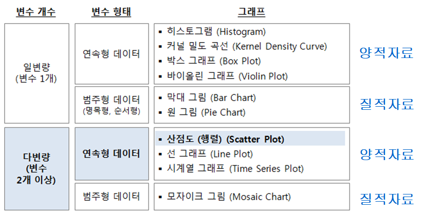

- 도수분포표 작성

# 2. 일변량 질적 자료의 분석

## 2.1 도수분포표 작성

```python
ans = c("Y","Y","N","Y","Y")
table(ans)                 # 도수분포표 출력

table(ans)/length(ans)     # 비율 출력
```

```
ans
N Y
1 4
```

```
ans
  N   Y
0.2 0.8
```

```python
table(iris$Species)
```

```
    setosa versicolor  virginica
        50         50         50
```

- 막대그래프 작성

## 2.2 막대그래프 작성

```python
favorite.color <- c("red", "green", "yellow", "red", "green", "red", "red")
sum <- table(favorite.color)     # 도수분포표
sum
```

```
favorite.color
 green    red yellow
     2      4      1
```

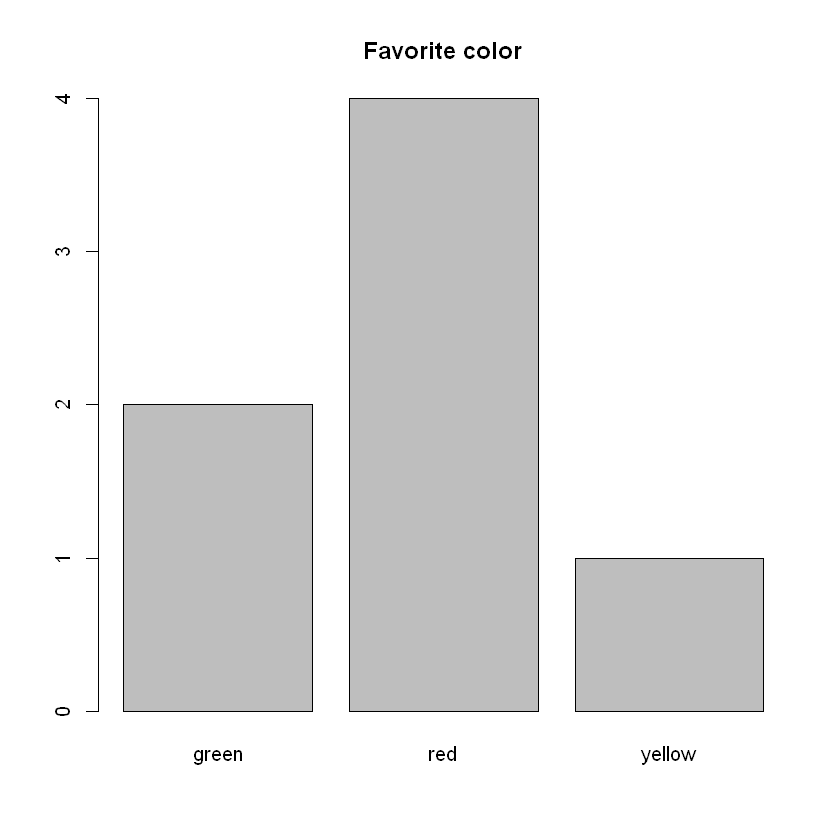

```python
 barplot(sum, main="Favorite color")
```

### 2.2.1 막대그래프 사례

A data.frame: 6 × 11

|  | mpg <dbl> | cyl <dbl> | disp <dbl> | hp <dbl> | drat <dbl> | wt <dbl> | qsec <dbl> | vs <dbl> | am <dbl> | gear <dbl> | carb <dbl> |
| --- | --- | --- | --- | --- | --- | --- | --- | --- | --- | --- | --- |
| Mazda RX4 | 21.0 | 6 | 160 | 110 | 3.90 | 2.620 | 16.46 | 0 | 1 | 4 | 4 |
| Mazda RX4 Wag | 21.0 | 6 | 160 | 110 | 3.90 | 2.875 | 17.02 | 0 | 1 | 4 | 4 |
| Datsun 710 | 22.8 | 4 | 108 | 93 | 3.85 | 2.320 | 18.61 | 1 | 1 | 4 | 1 |
| Hornet 4 Drive | 21.4 | 6 | 258 | 110 | 3.08 | 3.215 | 19.44 | 1 | 0 | 3 | 1 |
| Hornet Sportabout | 18.7 | 8 | 360 | 175 | 3.15 | 3.440 | 17.02 | 0 | 0 | 3 | 2 |
| Valiant | 18.1 | 6 | 225 | 105 | 2.76 | 3.460 | 20.22 | 1 | 0 | 3 | 1 |

```
carb
 1  2  3  4  6  8
 7 10  3 10  1  1
```

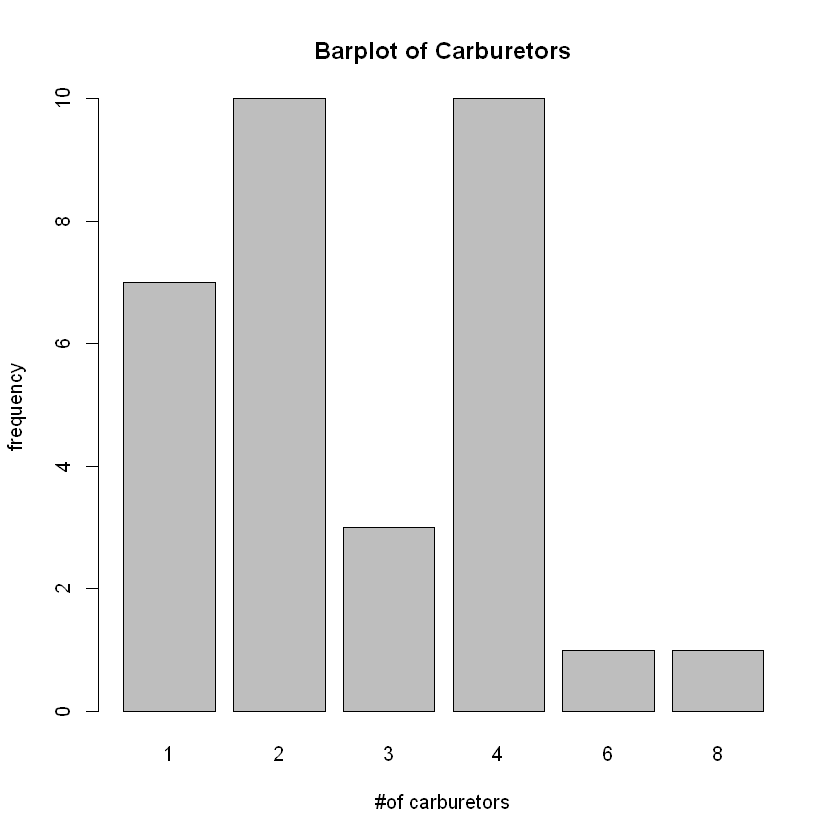

```python
head(mtcars)              # 자동차 모델별 제원
carb <- mtcars[,"carb"]   # 기화기 수
table(carb)               # 도수분포표
barplot(table(carb),
        main="Barplot of Carburetors",
        xlab="#of carburetors",
        ylab="frequency")

# table() : 주어진 자료로부터 도수 분포표를 그려준다.
```

### 2.2.2 barplot() 매개변수

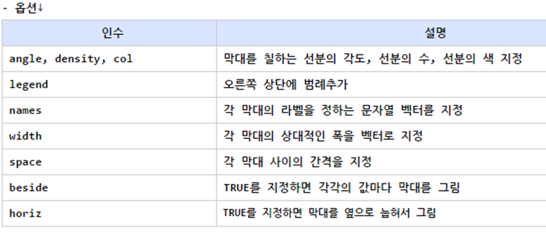

### 2.2.3 한 화면에 그래프 여러개 그리기

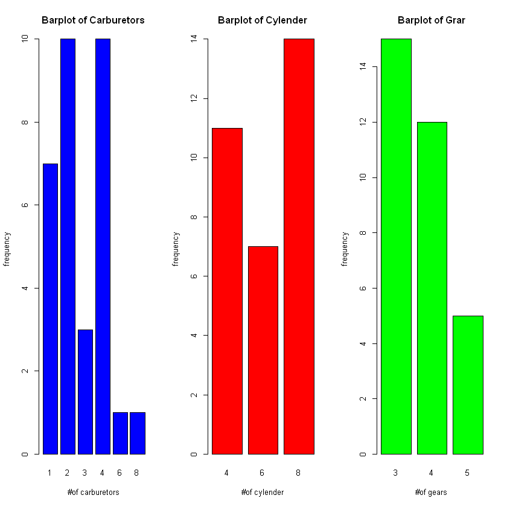

```python
par(mfrow=c(1,3))         # 1x3 윈도우 생성
barplot(table(mtcars$carb),
        main="Barplot of Carburetors",
        xlab="#of carburetors",
        ylab="frequency",
        col="blue")
barplot(table(mtcars$cyl),
        main="Barplot of Cylender",
        xlab="#of cylender",
        ylab="frequency",
        col="red")
barplot(table(mtcars$gear),
        main="Barplot of Grar",
        xlab="#of gears",
        ylab="frequency",
        col="green")
```

### 2.2.4 기타

barplot에 대한 상세한 옵션

```
? barplot
```

다양한 막대 그래프 예제  
http://www.theanalysisfactor.com/r-11-bar-charts/

R 에서 지원하는 color 이름  
http://www.stat.columbia.edu/~tzheng/files/Rcolor.pdf

## 2.3 연습

```
[1] "1번"
```

1. 0-5yrs

2. 0-5yrs

3. 0-5yrs

4. 0-5yrs

5. 6-11yrs

6. 6-11yrs

7. 6-11yrs

8. 6-11yrs

9. 6-11yrs

10. 6-11yrs

11. 6-11yrs

12. 6-11yrs

13. 6-11yrs

14. 6-11yrs

15. 6-11yrs

16. 6-11yrs

17. 6-11yrs

18. 6-11yrs

19. 6-11yrs

20. 6-11yrs

21. 6-11yrs

22. 6-11yrs

23. 6-11yrs

24. 6-11yrs

25. 6-11yrs

26. 6-11yrs

27. 6-11yrs

28. 6-11yrs

29. 6-11yrs

30. 6-11yrs

31. 6-11yrs

32. 6-11yrs

33. 6-11yrs

34. 6-11yrs

35. 6-11yrs

36. 6-11yrs

37. 6-11yrs

38. 6-11yrs

39. 6-11yrs

40. 6-11yrs

41. 6-11yrs

42. 6-11yrs

43. 6-11yrs

44. 6-11yrs

45. 12+ yrs

46. 12+ yrs

47. 12+ yrs

48. 12+ yrs

49. 12+ yrs

50. 12+ yrs

51. 12+ yrs

52. 12+ yrs

53. 12+ yrs

54. 12+ yrs

55. 12+ yrs

56. 12+ yrs

57. 12+ yrs

58. 12+ yrs

59. 12+ yrs

60. 12+ yrs

61. 12+ yrs

62. 12+ yrs

63. 12+ yrs

64. 12+ yrs

65. 12+ yrs

66. 12+ yrs

67. 12+ yrs

68. 12+ yrs

69. 12+ yrs

70. 12+ yrs

71. 12+ yrs

72. 12+ yrs

73. 12+ yrs

74. 12+ yrs

75. 12+ yrs

76. 12+ yrs

77. 12+ yrs

78. 12+ yrs

79. 12+ yrs

80. 12+ yrs

81. 12+ yrs

82. 12+ yrs

83. 12+ yrs

84. 0-5yrs

85. 0-5yrs

86. 0-5yrs

87. 0-5yrs

88. 6-11yrs

89. 6-11yrs

90. 6-11yrs

91. 6-11yrs

92. 6-11yrs

93. 6-11yrs

94. 6-11yrs

95. 6-11yrs

96. 6-11yrs

97. 6-11yrs

98. 6-11yrs

99. 6-11yrs

100. 6-11yrs

101. 6-11yrs

102. 6-11yrs

103. 6-11yrs

104. 6-11yrs

105. 6-11yrs

106. 6-11yrs

107. 6-11yrs

108. 6-11yrs

109. 6-11yrs

110. 6-11yrs

111. 6-11yrs

112. 6-11yrs

113. 6-11yrs

114. 6-11yrs

115. 6-11yrs

116. 6-11yrs

117. 6-11yrs

118. 6-11yrs

119. 6-11yrs

120. 6-11yrs

121. 6-11yrs

122. 6-11yrs

123. 6-11yrs

124. 6-11yrs

125. 6-11yrs

126. 6-11yrs

127. 6-11yrs

128. 12+ yrs

129. 12+ yrs

130. 12+ yrs

131. 12+ yrs

132. 12+ yrs

133. 12+ yrs

134. 12+ yrs

135. 12+ yrs

136. 12+ yrs

137. 12+ yrs

138. 12+ yrs

139. 12+ yrs

140. 12+ yrs

141. 12+ yrs

142. 12+ yrs

143. 12+ yrs

144. 12+ yrs

145. 12+ yrs

146. 12+ yrs

147. 12+ yrs

148. 12+ yrs

149. 12+ yrs

150. 12+ yrs

151. 12+ yrs

152. 12+ yrs

153. 12+ yrs

154. 12+ yrs

155. 12+ yrs

156. 12+ yrs

157. 12+ yrs

158. 12+ yrs

159. 12+ yrs

160. 12+ yrs

161. 12+ yrs

162. 12+ yrs

163. 12+ yrs

164. 12+ yrs

165. 12+ yrs

166. 0-5yrs

167. 0-5yrs

168. 0-5yrs

169. 0-5yrs

170. 6-11yrs

171. 6-11yrs

172. 6-11yrs

173. 6-11yrs

174. 6-11yrs

175. 6-11yrs

176. 6-11yrs

177. 6-11yrs

178. 6-11yrs

179. 6-11yrs

180. 6-11yrs

181. 6-11yrs

182. 6-11yrs

183. 6-11yrs

184. 6-11yrs

185. 6-11yrs

186. 6-11yrs

187. 6-11yrs

188. 6-11yrs

189. 6-11yrs

190. 6-11yrs

191. 6-11yrs

192. 6-11yrs

193. 6-11yrs

194. 6-11yrs

195. 6-11yrs

196. 6-11yrs

197. 6-11yrs

198. 6-11yrs

199. 6-11yrs

200. 6-11yrs

201. 6-11yrs

202. 6-11yrs

203. 6-11yrs

204. 6-11yrs

205. 6-11yrs

206. 6-11yrs

207. 6-11yrs

208. 6-11yrs

209. 6-11yrs

210. 12+ yrs

211. 12+ yrs

212. 12+ yrs

213. 12+ yrs

214. 12+ yrs

215. 12+ yrs

216. 12+ yrs

217. 12+ yrs

218. 12+ yrs

219. 12+ yrs

220. 12+ yrs

221. 12+ yrs

222. 12+ yrs

223. 12+ yrs

224. 12+ yrs

225. 12+ yrs

226. 12+ yrs

227. 12+ yrs

228. 12+ yrs

229. 12+ yrs

230. 12+ yrs

231. 12+ yrs

232. 12+ yrs

233. 12+ yrs

234. 12+ yrs

235. 12+ yrs

236. 12+ yrs

237. 12+ yrs

238. 12+ yrs

239. 12+ yrs

240. 12+ yrs

241. 12+ yrs

242. 12+ yrs

243. 12+ yrs

244. 12+ yrs

245. 12+ yrs

246. 12+ yrs

247. 12+ yrs

248. 12+ yrs

**Levels**:**

1. '0-5yrs'

2. '6-11yrs'

3. '12+ yrs'

```
[1] "2번"
```

1. 0-5yrs

2. 6-11yrs

3. 12+ yrs

**Levels**:**

1. '0-5yrs'

2. '6-11yrs'

3. '12+ yrs'

```
[1] "3번"
```

```
edu
 0-5yrs 6-11yrs 12+ yrs
     12     120     116
```

```
[1] "4번"
```

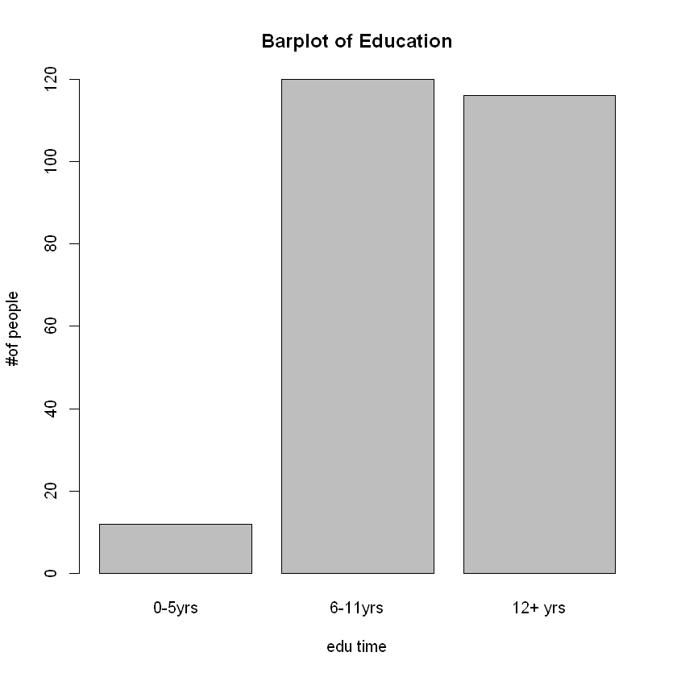

```python
print("1번")
edu <- infert[,"education"]
edu

print("2번")
unique(edu)

print("3번")
table(edu)

print("4번")

barplot(table(edu),
        main="Barplot of Education",
        xlab="edu time",
        ylab="#of people")
```

## 2.4 원 그래프 작성

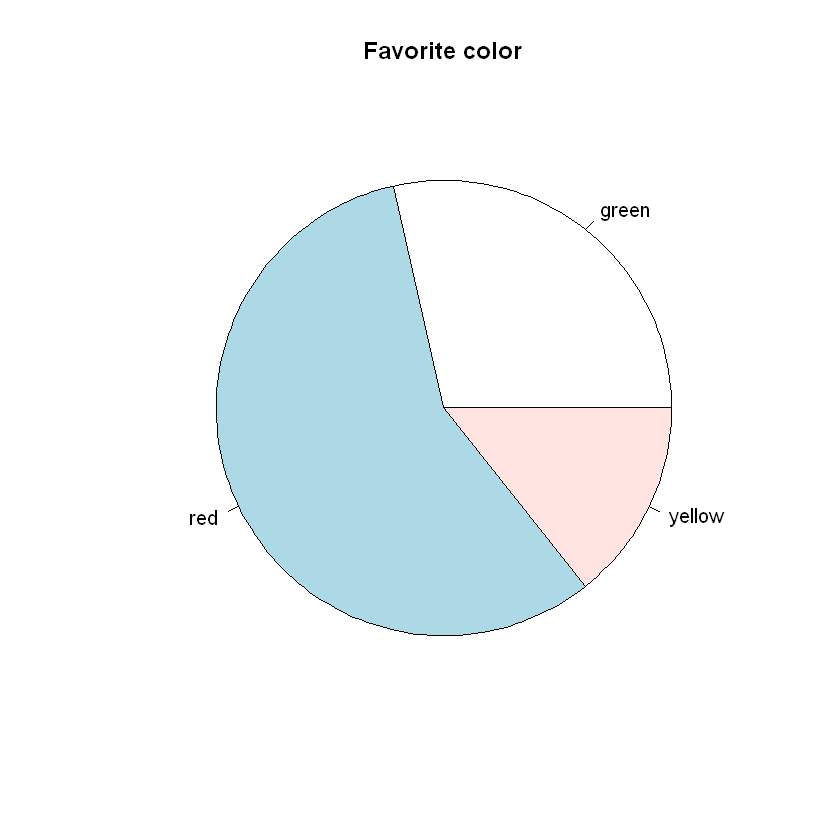

```python
favorite.color <- c("red", "green", "yellow", "red", "green", "red", "red")
sum <- table(favorite.color )     # 도수분포표
pie(sum, main="Favorite color")
```

# 3. 일변량 양적 자료의 분석

양적자료는 질적 자료에 비해 분석 방법이 많다

- 평균/중앙값
- 4분위수
- 분산, 표준편차
- Boxplot
- Histogram
- 나무-잎 그림

## 3.1 평균

평균(mean)

- 균형점, 무게중심

중앙값(median)

- 어떤 주어진 값들을 정렬했을 때 가장 중앙에 위치하는 값을 의미
  - 전체 자료의 개수(n)이 홀수 일 때, (n+1)/2 번쨰 값
  - 전체 자료의 개수(n)이 짝수 일 때, n/2 번째와 (n/2 + 1) 번째 값의 평균

절사평균(trimmed mean)

- 표본중에서 작은값 n% 와 큰값 n%를 제외하고 나머지 (100-2n)% 의 자료만 사용하여 구한 평균

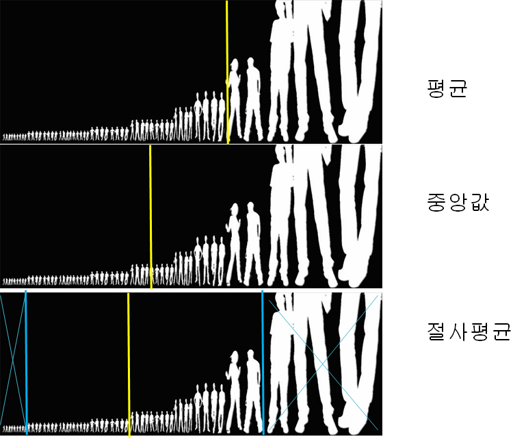

## 3.2 4분위 수

4분위수 (quartile) : 측정값을 4등분하는 백분위수

- 제 1 사분위수 (Q1) : 제 25 백분위수
- 제 2 사분위수 (Q2) : 제 50 백분위수, 중앙값
- 제 3 사분위수 (Q3) : 제 75 백분위수

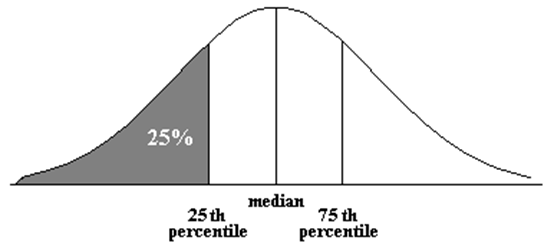

### 3.2.2 관련 함수

```python
mydata = c(50,60,100,75,200)
mydata.big = c(mydata, 50000)

mean(mydata)                                  # 평균
mean(mydata.big)

median(mydata)                              # 중앙값
median(mydata.big)

mean(mydata, trim=0.2)      # 절사평균
mean(mydata.big, trim=0.2)

quantile(mydata)                          # 사분위수
quantile(mydata, (0:10)/10)

summary(mydata)
fivenum(mydata)             # quantile()과 비슷
```

97

8414.16666666667

75

87.5

78.3333333333333

108.75

**0%**

50

**25%**

60

**50%**

75

**75%**

100

**100%**

200

**0%**

50

**10%**

54

**20%**

58

**30%**

63

**40%**

69

**50%**

75

**60%**

85

**70%**

95

**80%**

120

**90%**

160

**100%**

200

```
   Min. 1st Qu.  Median    Mean 3rd Qu.    Max.
     50      60      75      97     100     200
```

1. 50

2. 60

3. 75

4. 100

5. 200

## 3.3 산포

산포 (distribution)

- 데이터가 퍼져 있는 정도, 흩어져 있는 정도
- 분산과 표준편차를 가지고 표현

분산 (variance)

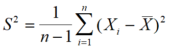

표준편차(standard deviation)

### 3.3.1 관련 함수

```python
diff(range(mydata))    # 최대값-최소값
var(mydata)            # 분산
sd(mydata)             # 표준편차
```

150

3670

60.5805249234438

## 3.4 상자 그림(box plot)

Box plot 또는 Box whisker plot

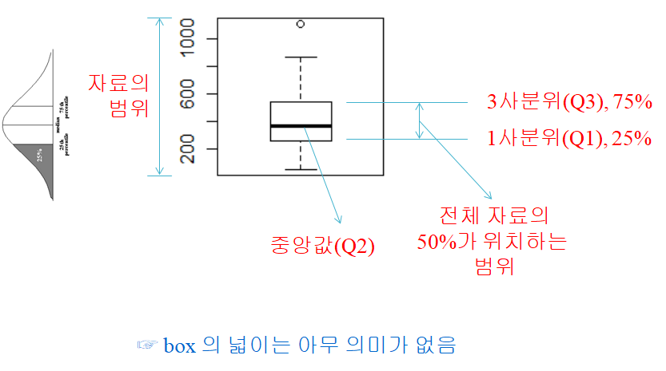

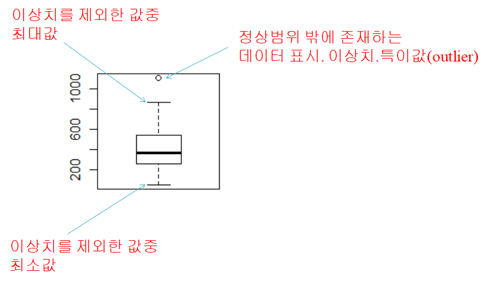

### 3.4.1 예제1

state.x77 데이터셋에서 주별 소득을 boxplot으로 그리기

A matrix: 6 × 8 of type dbl

|  | Population | Income | Illiteracy | Life Exp | Murder | HS Grad | Frost | Area |
| --- | --- | --- | --- | --- | --- | --- | --- | --- |
| Alabama | 3615 | 3624 | 2.1 | 69.05 | 15.1 | 41.3 | 20 | 50708 |
| Alaska | 365 | 6315 | 1.5 | 69.31 | 11.3 | 66.7 | 152 | 566432 |
| Arizona | 2212 | 4530 | 1.8 | 70.55 | 7.8 | 58.1 | 15 | 113417 |
| Arkansas | 2110 | 3378 | 1.9 | 70.66 | 10.1 | 39.9 | 65 | 51945 |
| California | 21198 | 5114 | 1.1 | 71.71 | 10.3 | 62.6 | 20 | 156361 |
| Colorado | 2541 | 4884 | 0.7 | 72.06 | 6.8 | 63.9 | 166 | 103766 |

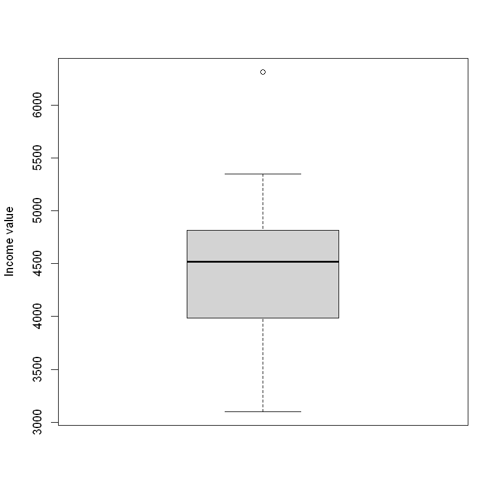

```python
head(state.x77)
st.income <- state.x77[,"Income"]
boxplot(st.income, ylab="Income value")
```

### 3.4.2 예제2

iris dataset에서 품종(Species)에 따른 Petal.Width 자료에 대한 boxplot 그리기

A data.frame: 6 × 5

|  | Sepal.Length <dbl> | Sepal.Width <dbl> | Petal.Length <dbl> | Petal.Width <dbl> | Species <fct> |
| --- | --- | --- | --- | --- | --- |
| 1 | 5.1 | 3.5 | 1.4 | 0.2 | setosa |
| 2 | 4.9 | 3.0 | 1.4 | 0.2 | setosa |
| 3 | 4.7 | 3.2 | 1.3 | 0.2 | setosa |
| 4 | 4.6 | 3.1 | 1.5 | 0.2 | setosa |
| 5 | 5.0 | 3.6 | 1.4 | 0.2 | setosa |
| 6 | 5.4 | 3.9 | 1.7 | 0.4 | setosa |

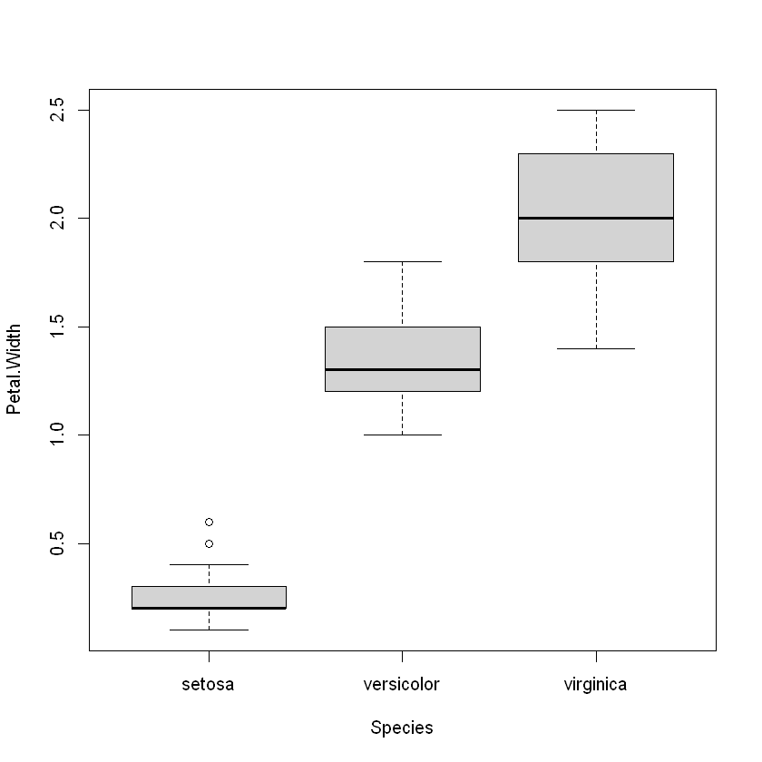

```python
head(iris)
boxplot(Petal.Width~Species, data=iris, ylab="Petal.Width")
```

## 3.5 히스토그램

막대 그래프는 도수 분포표를 만들 수 있는 정수형, 문자형 자료의 경우에 사용하고, 실수형 자료에 대해서는 히스토그램을 사용한다

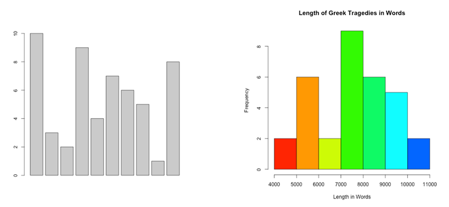

막대그래프는 막대간 간격이 있고 막대의 면적은 의미가 없다.  
히스토그램은 막대가 붙어 있고 막대의 면적이 의미가 있다.

### 3.5.1 히스토그램 그리기

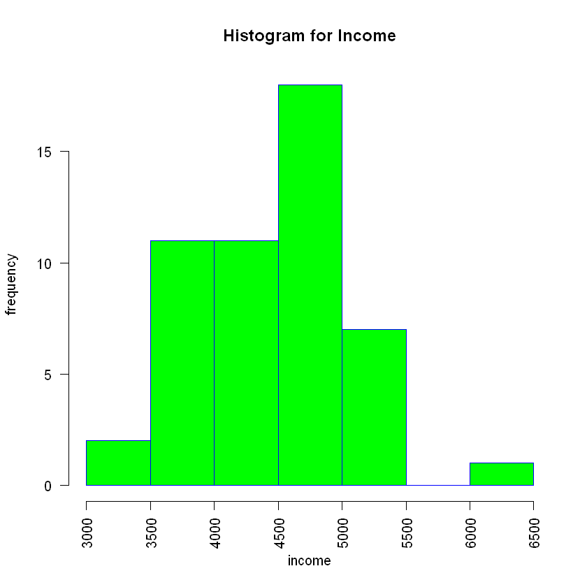

```python
st.income <- state.x77[,"Income"]
hist(st.income,                      # data
     main="Histogram for Income",    # 제목
     xlab ="income",    # x축 레이블
     ylab="frequency",  # y축 레이블
     border="blue",     # 막대 테두리색
     col="green",       # 막대 색
     las=2,             # x축 글씨방향(0~3)
     breaks=5)          # x축 막대 개수 조절
```

## 3.6 줄기-잎 그림

```python
score <- c(40,55,90,75,59,60,63,65,69,71)
stem(score, scale=2)
```

```
  The decimal point is 1 digit(s) to the right of the |

  4 | 0
  5 | 59
  6 | 0359
  7 | 15
  8 |
  9 | 0
```

Scale 값이 커지면 줄기의 수 증가 (줄기당 잎 수 감소)

```python
stem(score, scale=1)
```

```
  The decimal point is 1 digit(s) to the right of the |

  4 | 059
  6 | 035915
  8 | 0
```

```python
stem(score, scale=3)
```

```
  The decimal point is 1 digit(s) to the right of the |

  4 | 0
  4 |
  5 |
  5 | 59
  6 | 03
  6 | 59
  7 | 1
  7 | 5
  8 |
  8 |
  9 | 0
```

## 3.7 연습

### 3.7.1 문제 1

홍길동군의 과목별 성적은 다음과 같다.

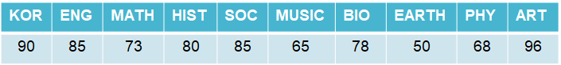

1.이 데이터를 score 벡터에 저장하시오. (과목명은 데이터 이름으로 저장하시오)

```python
hong <- c(90,85,73,80,85,65,78,50,68,96)
names(hong) <- c("KOR", "ENG", "MATH", "HIST", "SOC", "MUSIC", "BIO", "EARTH", "PHY", "ART")
```

2.score 벡터의 내용을 보이시오

```python
hong
```

**KOR**

90

**ENG**

85

**MATH**

73

**HIST**

80

**SOC**

85

**MUSIC**

65

**BIO**

78

**EARTH**

50

**PHY**

68

**ART**

96

3.전체 성적의 평균은 얼마인가

```python
mean(hong)
```

77

4.전체 성적의 중앙값은 얼마인가

```python
median(hong)
```

79

5.전체 성적의 표준편차를 보이시오

```python
sd(hong)
```

13.490737563232

6.가장 성적이 높은 과목의 이름을 보이시오

```python
which.max(hong)
```

**ART:** 10

7.성적에 대한 boxplot 을 그리시오. 이상치에 해당하는 과목이 있으면 제시하시오

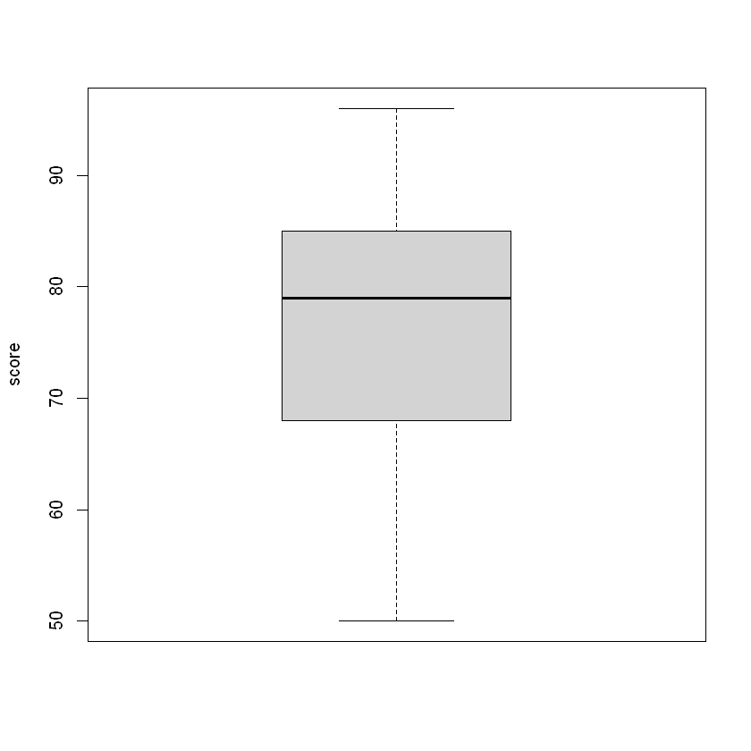

```python
boxplot(hong, ylab="score")
```

8.성적에 대한 histogram 을 그리되 다음조건을 만족하도록 하시오  
(그래프 title : Hong’s score, 막대색: 보라색)

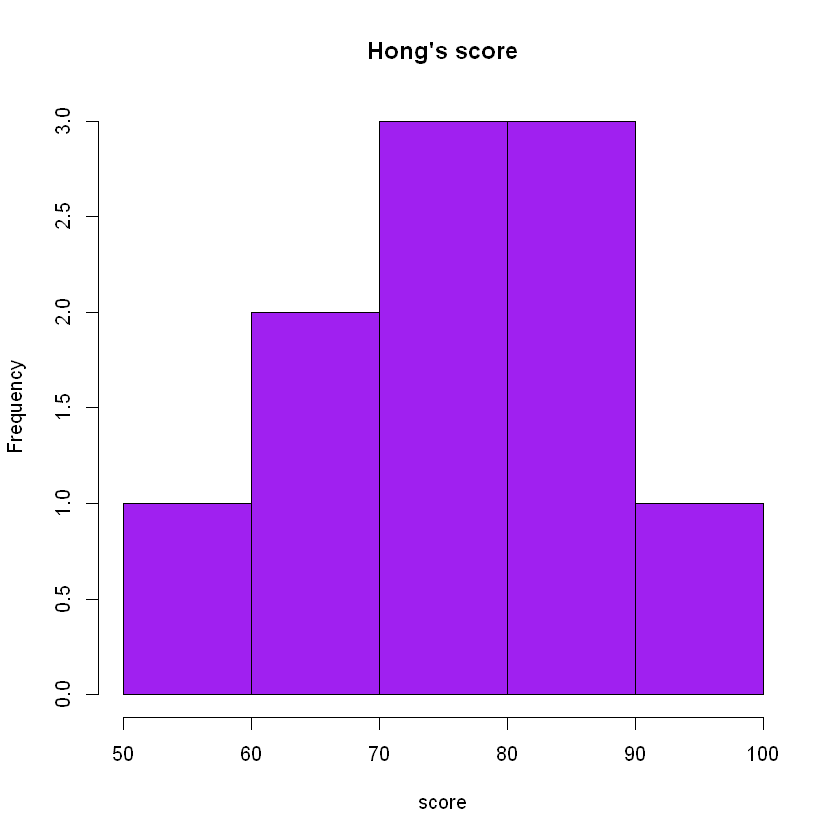

```python
hist(hong,
     main="Hong's score",
     xlab="score",
     col="purple"

    )
```

### 3.7.2 문제2

mtcars 데이터셋을 이용하여 다음 문제를 해결하시오

1.중량(wt) 의 평균값, 중앙값, 절사평균값(절사범위:15%), 표준편차 를 구하시오

```python
weight <- mtcars[,"wt"]

mean(weight)
median(weight)
mean(weight, trim=0.15)
sd(weight)
```

3.21725

3.325

3.16520833333333

0.978457442989697

2.중량(wt)에 대해 summary() 함수의 적용 결과를 보이시오

```python
summary(weight)
```

```
   Min. 1st Qu.  Median    Mean 3rd Qu.    Max.
  1.513   2.581   3.325   3.217   3.610   5.424
```

3.실린더수(cyl) 에 대해 도수분포표를 구하시오

```python
cyl <- mtcars[,"cyl"]

table(cyl)
```

```
cyl
 4  6  8
11  7 14
```

4.앞에서 구한 도수분포표를 막대그래프로 그려 보시오

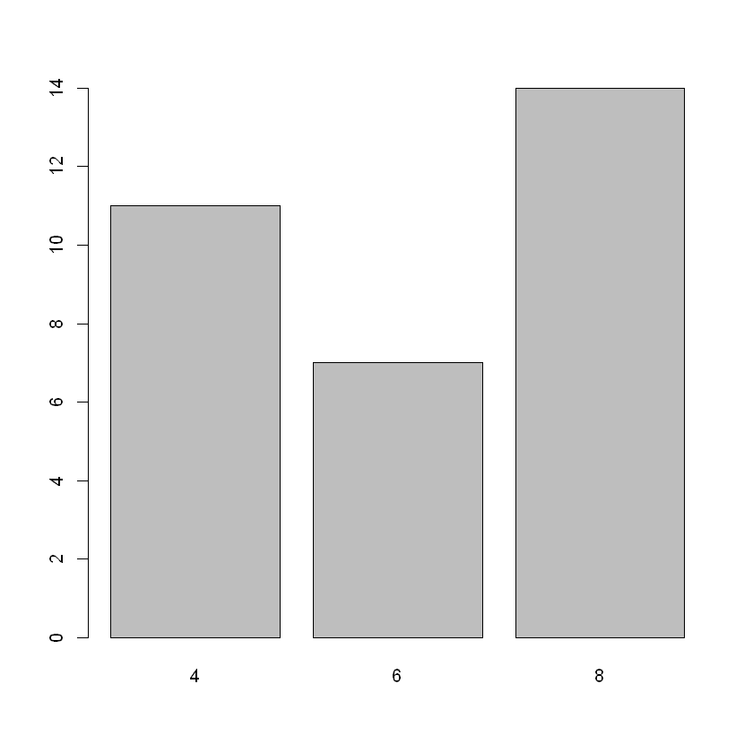

```python
barplot(table(cyl))
```

5.중량(wt)의 히스토그램, 실린더(cyl), 기어(gear) 에 대한 막대 그래프를 한 화면에 보이게 작성하시오

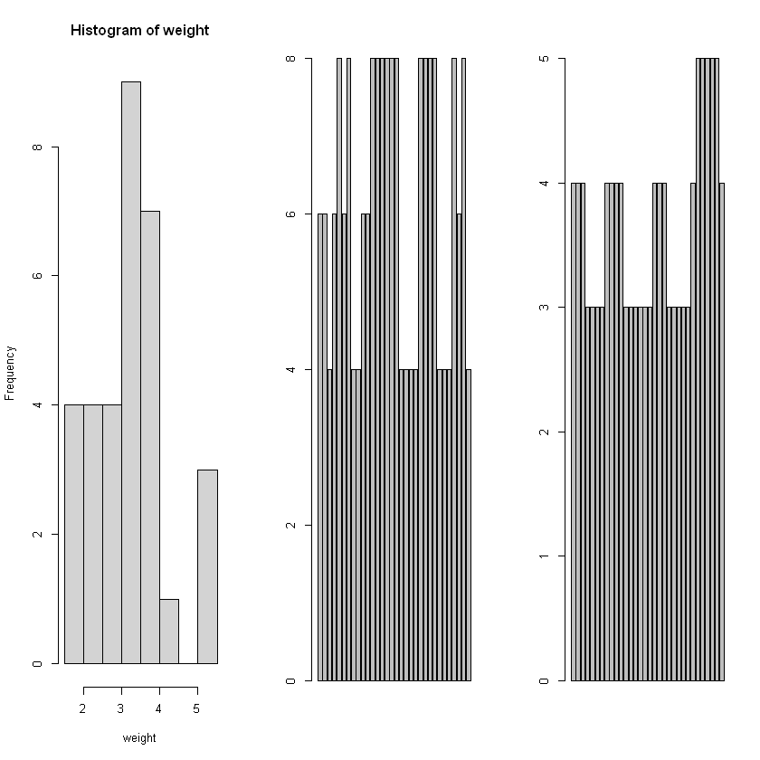

```python
par(mfrow=c(1,3))
hist(weight)
barplot(cyl)
barplot(mtcars[,"gear"])
```

6.중량(wt)에 대해 boxplot 을 그려 보시오. Boxplot 으로 부터 관찰할 수 있는 정보를 적으시오

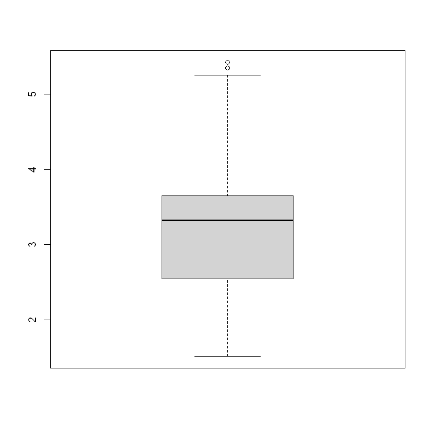

```python
boxplot(weight)
# 이상치 2개가 있다
# 3사분위, 1사분위 사이의 자료(전체자료의 50%)는 4보다 작고 2보다 크다
# 중앙값(Q2)은 3보다 크다
# 이상치를 제외한 최솟값은 2보다 작고, 최댓값은 5보다 크다
```

7.배기량(disp)에 대해 boxplot 을 그려 보시오. Boxplot 으로 부터 관찰할 수 있는 정보를 적으시오

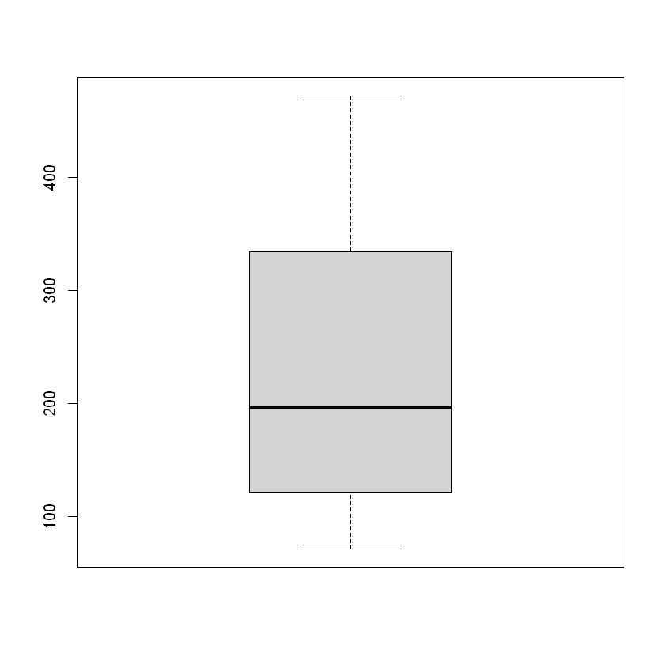

```python
boxplot(mtcars[,"disp"])
# 중앙값(Q2)은 약 200
# 최대값은 400이상, 최솟값은 100 이하
# 이상치 없음
# 3사분위, 1사분위 사이의 자료(전체자료의 50%)는 100보다 크고 350보다는 작다
```

```python
%%javascript
$.getScript('https://kmahelona.github.io/ipython_notebook_goodies/ipython_notebook_toc.js')
```